# Using `SpaDES.addins` with RStudio

Alex M. Chubaty

August 19 2022

# 1 Using RStudio addins

RStudio addins provide a graphical interface for performing common tasks. After installing the `SpaDES.addins` package, go to the Addins menu in the RStudio IDE to see the list of available addins provided by this package.

[figure not shown]

You can assign keyboard shortcuts to any of these addins if you wish. See https://rstudio.github.io/rstudioaddins/#running-addins.

## 1.1 `SpaDES` module directory

The default module directory is a temporary one, and can be changed using `SpaDES.core::setPaths()`. See `?SpaDES.core::setPaths` for details.

We recommend using a single local directory for your `SpaDES` modules. Thus, only a single module directory is specified when using these addins.

# 2 `SpaDES` module development

## 2.1 Copy an existing module

The simplest way to get started on developing a `SpaDES` module, is to start from an existing module. Anytime you wish to modify an existing module, we suggest working from a copy, rather than modifying the existing module directly. To copy an existing module, simply invoke the *SpaDES: copy module* addin from the RStudio Addins menu.

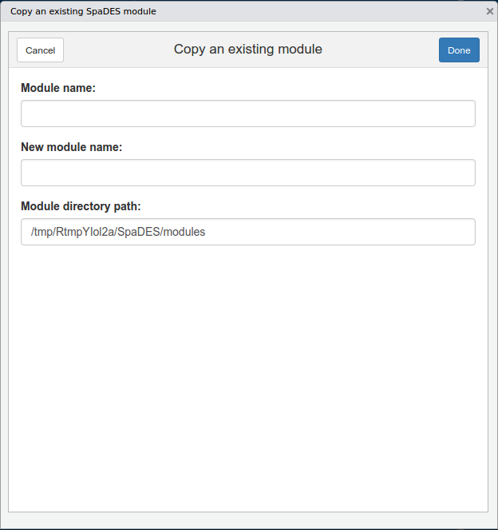

## 2.2 Create a new `SpaDES` module from a template

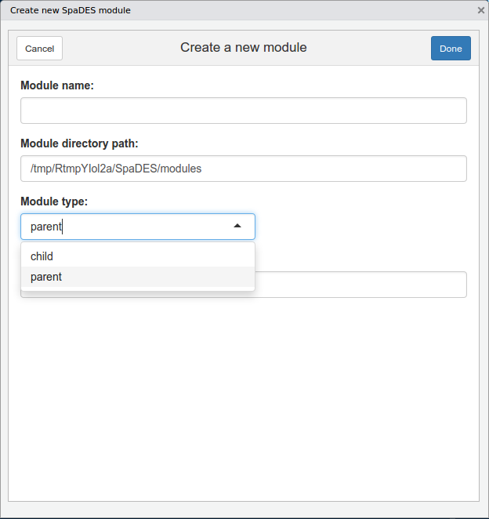

# 3 `SpaDES` package development (advanced)

More advanced users planning on contributing code to the `SpaDES` ecosystem of packages, can make use of additional package development tools.